# Descriptive overview of LLM extractions: run 0414

Zhongtian Sun, Maxwell J. Farrell, Liam Brierley

April 20 2025

#### Check all 100 docs are present in each file:

```
## [1] 100
```

```
## [1] 100
```

```
## [1] 100
```

```
## [1] 100
```

```
## [1] 100
```

```
## [1] 100
```

```
## [1] 100
```

```
## [1] 100
```

#### Are there duplicated rows in any model outputs?

*Should be zero.*

|  | Duplicated entitity rows | Duplicated relation rows |
| --- | --- | --- |
| deepseek | 0 | 0 |
| gemma2 | 0 | 0 |
| llama | 0 | 0 |
| llama70b | 0 | 0 |
| mistral | 0 | 0 |

### Average entities/relations per doc

*Much more consistent now removing rtype errors (relation types being included in entity types). Long tail of some abstracts with many relations, captured by all models though mistral captures more still.*

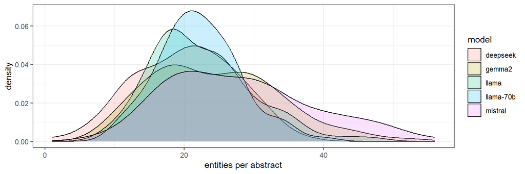

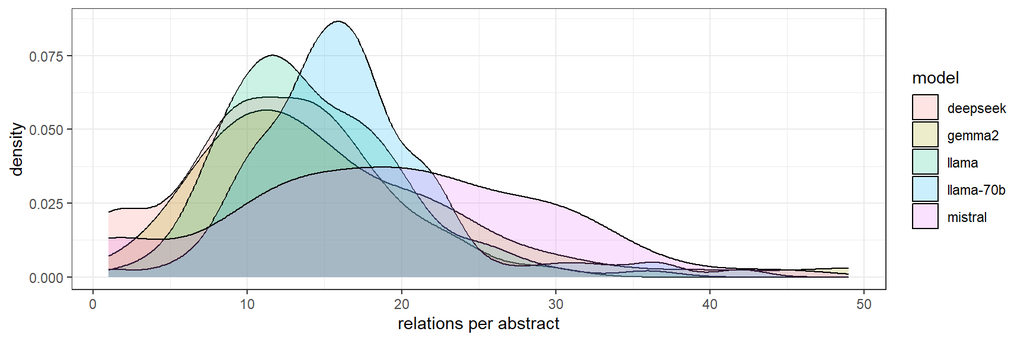

### Most common types of entities

**Note only plotted if a given threshold PER MODEL**

*Note “Unknown” and “Undefined” present at quite high frequency in Mistral, Gemma, Deepseek. Most seem to be numerical values or acronyms for all models - except Deepseek, which is failing some pretty easy ones - see below.*

*“Proportion of individuals that died”* *is just being used to mean proportion of individuals, maybe even just proportion. This happens for models other than mistral too.*

*This is surely being driven by our prompt example output….*

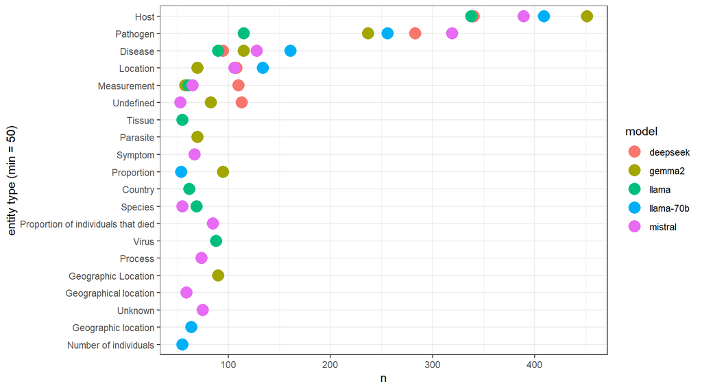

```r
ent_m %>% filter(type == "Unknown") %>% slice(1:25)
```

```
##    entity_id      entity    type doc_id
## 1         29        2001 Unknown  59826
## 2         32          31 Unknown  59826
## 3         33          30 Unknown  59826
## 4         34          28 Unknown  59826
## 5         35          20 Unknown  59826
## 6         36         109 Unknown  59826
## 7         58          14 Unknown  58605
## 8         65          36 Unknown  58605
## 9        144        2001 Unknown  59578
## 10       147        June Unknown  59578
## 11       149          20 Unknown  59578
## 12       209         111 Unknown  59842
## 13       249        role Unknown  59912
## 14       322        2001 Unknown  59836
## 15       373         DGA Unknown  59858
## 16       375       GA1UR Unknown  59858
## 17       410        June Unknown  56169
## 18       413        4000 Unknown  56169
## 19       498        2001 Unknown  57733
## 20       596         881 Unknown  56805
## 21       598 Hurstbridge Unknown  56805
## 22       625     A21JP2T Unknown  57753
## 23       652       1:128 Unknown  59860
## 24       687         119 Unknown  59886
## 25       691          20 Unknown  59886
```

```r
ent_d %>% filter(type == "Undefined") %>% slice(1:25)
```

```
##    entity_id                    entity      type doc_id
## 1         60        African ecosystems Undefined  58605
## 2         64                island fox Undefined  59699
## 3         77       antibody prevalence Undefined  59699
## 4         90          16 of 17 chamois Undefined  59904
## 5        100                        20 Undefined  59578
## 6        110                 Uric acid Undefined  59831
## 7        120      Necropsy examination Undefined  59831
## 8        121            Histopathology Undefined  59831
## 9        154                game areas Undefined  59912
## 10       180                 Fall 1991 Undefined  59921
## 11       193 serum antibody prevalence Undefined  58455
## 12       197                      1984 Undefined  58455
## 13       201              productivity Undefined  58455
## 14       219           seroconversions Undefined  59903
## 15       258         white blood cells Undefined  59858
## 16       269              Cape buffalo Undefined  56169
## 17       319             incident case Undefined  59823
## 18       321      group size reduction Undefined  59823
## 19       325                     males Undefined  59823
## 20       342                prevalence Undefined  57733
## 21       348             serum samples Undefined  59859
## 22       357                       150 Undefined  59859
## 23       360                         4 Undefined  59859
## 24       386                     rural Undefined  56805
## 25       414       antibody prevalence Undefined  59860
```

### Compare entity types for same entity texts WITHIN models

*How many entity types is each entity text associated with within each model? 2-3% of entities have >1 type. Ideal is zero?*

| model | 1 | 2 | 3 | 4 |
| --- | --- | --- | --- | --- |
| deepseek | 96.5 | 3.1 | 0.3 | 0.1 |
| gemma2 | 98.2 | 1.7 | 0.0 | NA |
| llama | 97.5 | 2.2 | 0.3 | NA |
| llama70b | 98.5 | 1.4 | 0.1 | NA |
| mistral | 97.8 | 1.8 | 0.5 | NA |

*Example entities with >1 type within model:*

```r
ent_l %>% filter(entity %in% (ent_l %>% group_by(entity) %>% summarise(nt = n_distinct(type)) %>% filter(nt>1) %>% pull(entity))) %>% arrange(desc(entity)) %>% select(-entity_id, -doc_id) %>% distinct %>% slice(1:20)
```

```
##                              entity                        type
## 1                               sex   Biological characteristic
## 2                               sex         Host characteristic
## 3                         schizonts           Stage of parasite
## 4                         schizonts         Developmental stage
## 5                          protozoa               Microorganism
## 6                          protozoa                       Group
## 7                          primates                        Host
## 8                          primates                       Group
## 9                        prevalence                  Proportion
## 10                       prevalence                 Measurement
## 11        polymerase chain reaction                     Process
## 12        polymerase chain reaction Molecular biology technique
## 13                       phagocytes                 Immune cell
## 14                       phagocytes                   Cell type
## 15                              one                    Duration
## 16                              one                      Number
## 17 nested polymerase chain reaction                   Technique
## 18 nested polymerase chain reaction                     Process
## 19            monoclonal antibodies           Therapeutic agent
## 20            monoclonal antibodies                 Measurement
```

### Compare entity types for same entity texts BETWEEN models

*ONLY for entities having a single type within models (i.e., 1’s in table above).*

|  | 1 | 2 | 3 | 4 | 5 |
| --- | --- | --- | --- | --- | --- |
| 5 | 173 | 240 | 148 | 75 | 40 |
| 4 | 153 | 162 | 129 | 73 | 0 |
| 3 | 129 | 161 | 169 | 0 | 0 |
| 2 | 263 | 455 | 0 | 0 | 0 |
| 1 | 1593 | 0 | 0 | 0 | 0 |

*Example entity with varying and non-varying types between models. Full entity-by-entity sheet is in file *model_entity_type_comparison.csv**

```r
ent_type_comp %>% filter(models_present == 5 & n_entity_types == 1) %>% sample_n(1)
```

```
## # A tibble: 1 × 8
##   entity       deepseek gemma2  llama   llama70b mistral models_present n_entity_types
##   <chr>        <chr>    <chr>   <chr>   <chr>    <chr>            <dbl>          <int>
## 1 Pseudorabies Disease  Disease Disease Disease  Disease              5              1
```

```r
ent_type_comp %>% filter(models_present == 5 & n_entity_types == 5) %>% sample_n(1)
```

```
## # A tibble: 1 × 8
##   entity   deepseek gemma2                      llama    llama70b mistral models_present n_entity_types
##   <chr>    <chr>    <chr>                       <chr>    <chr>    <chr>            <dbl>          <int>
## 1 RGV-9506 Strain   Potential Drug or Treatment Pathogen Virus    Unknown              5              5
```

### Most common types of relations

*Relations look pretty much as they should. Some generic ones still.*

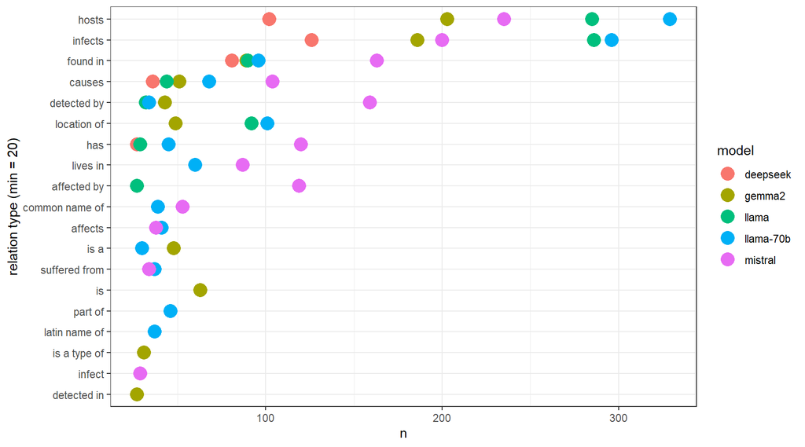

### Examine Latin name of/common name of relations

*ALL MODELS have directional errors in common/latin name of, e.g.:. This is probably then easiest to harmonise with RAG or external referencing or even embedding idea*

```r
rel_ll %>% filter(relation_type == "common name of") %>% slice(1:10)
```

```
##               source_text            target_text  relation_type doc_id
## 1              island fox     Urocyon littoralis common name of  59699
## 2     Rupicapra pyrenaica       southern chamois common name of  59578
## 3              black bear       Ursus americanus common name of  59921
## 4  Rocky Mountain cougars          Puma concolor common name of  59903
## 5       white-tailed deer Odocoileus virginianus common name of  59858
## 6             polar bears        Ursus maritimus common name of  57733
## 7       White-tailed deer Odocoileus virginianus common name of  59859
## 8    Amblyomma americanum         Lone star tick common name of  59859
## 9          Lone star tick   Amblyomma americanum common name of  59859
## 10      White-tailed deer Odocoileus virginianus common name of  59860
```

### Abstracts missing predefined entity and relation types:

*Seem to be more missing Host/Pathogens this extraction… Llama-70b appears best again here.*

*Seems a mix of possible synonyms for “host” and “infect”, e.g., found in” “is affected by”, “are hosts of”, etc. within the above but need to validate fully to confirm this - IF we do indeed want to do full relation validation (instead of just a priori harmonising).*

|  | Abs with no ‘Host’ entity | Abs with no ‘Pathogen’ entity | Abs with no ‘hosts’ relation | Abs with no ‘infects’ relation | Abs with neither relation |
| --- | --- | --- | --- | --- | --- |
| deepseek | 6 | 3 | 51 | 47 | 46 |
| gemma2 | 0 | 14 | 25 | 24 | 23 |
| llama | 6 | 40 | 2 | 3 | 0 |
| llama70b | 0 | 7 | 1 | 3 | 1 |
| mistral | 4 | 7 | 17 | 19 | 16 |

*The single llama-70b with no host-parasite relation is curious. The abstract definitely has much more content. Did it give up after finding a single “no relationship” relation?*

```r
rel_ll %>% filter(doc_id == (rel_ll %>% filter(!(doc_id %in% c(rel_ll %>% filter(relation_type == "hosts"|relation_type == "infects") %>% pull(doc_id)))) %>% pull(doc_id)))
```

```
##   source_text target_text   relation_type doc_id
## 1  Antibodies  Antibodies no_relationship  59912
```

*Where else is “no_relationship” seen? Seems to be in all other models, and always when source and targets are same, e.g….*

```r
rel_d %>% filter(relation_type == "no_relationship")
```

```
##                     source_text                  target_text   relation_type doc_id
## 1                  rabies virus                 rabies virus no_relationship  58605
## 2                   Herpesvirus                  Herpesvirus no_relationship  59830
## 3        Rocky Mountain cougars       Rocky Mountain cougars no_relationship  59903
## 4                  Papio anubis                 Papio anubis no_relationship  60194
## 5          long-tailed macaques         long-tailed macaques no_relationship  60248
## 6                       coyotes                      coyotes no_relationship  60155
## 7                       habitat                      habitat no_relationship  60306
## 8      western lowland gorillas     western lowland gorillas no_relationship  60223
## 9  legacy of low-impact logging legacy of low-impact logging no_relationship  60460
## 10                 Yellow fever                 Yellow fever no_relationship  58382
```

### Find any relations whose source or target entity do not appear in the matching entities file

*Should be zero for all - seems the 1 here is a numerical entity*

|  | Abs with ‘Source’ not in entities | Abs with ‘Target’ not in entities |
| --- | --- | --- |
| deepseek | 0 | 1 |
| gemma2 | 0 | 0 |
| llama | 0 | 0 |
| llama70b | 0 | 0 |
| mistral | 0 | 0 |